# Risk Factor Analysis

## Outcome Variable

**Outcome Variable:** pers_wasted624

## Predictor Variables

**Intervention Variable:** ever_underweight06

**Adjustment Set:**

- sex
- arm
- enstunt
- month
- brthmon
- vagbrth
- single
- W_gagebrth
- W_birthwt
- W_birthlen
- W_mage
- W_mhtcm
- W_meducyrs
- W_feducyrs
- W_parity
- delta_month
- delta_brthmon
- delta_vagbrth
- delta_single
- delta_W_gagebrth
- delta_W_birthwt
- delta_W_birthlen
- delta_W_mage
- delta_W_mhtcm
- delta_W_meducyrs
- delta_W_feducyrs
- delta_W_parity

## Stratifying Variables

The analysis was stratified on these variable(s):

- studyid
- country

## Data Summary

| studyid | country | ever_underweight06 | pers_wasted624 | n_cell | n |
| --- | --- | --- | --- | --- | --- |
| ki0047075b-MAL-ED | BANGLADESH | 0 | 0 | 160 | 240 |
| ki0047075b-MAL-ED | BANGLADESH | 0 | 1 | 3 | 240 |
| ki0047075b-MAL-ED | BANGLADESH | 1 | 0 | 62 | 240 |
| ki0047075b-MAL-ED | BANGLADESH | 1 | 1 | 15 | 240 |
| ki0047075b-MAL-ED | BRAZIL | 0 | 0 | 193 | 207 |
| ki0047075b-MAL-ED | BRAZIL | 0 | 1 | 2 | 207 |
| ki0047075b-MAL-ED | BRAZIL | 1 | 0 | 12 | 207 |
| ki0047075b-MAL-ED | BRAZIL | 1 | 1 | 0 | 207 |
| ki0047075b-MAL-ED | INDIA | 0 | 0 | 140 | 235 |
| ki0047075b-MAL-ED | INDIA | 0 | 1 | 1 | 235 |
| ki0047075b-MAL-ED | INDIA | 1 | 0 | 67 | 235 |
| ki0047075b-MAL-ED | INDIA | 1 | 1 | 27 | 235 |
| ki0047075b-MAL-ED | NEPAL | 0 | 0 | 196 | 235 |
| ki0047075b-MAL-ED | NEPAL | 0 | 1 | 0 | 235 |
| ki0047075b-MAL-ED | NEPAL | 1 | 0 | 37 | 235 |
| ki0047075b-MAL-ED | NEPAL | 1 | 1 | 2 | 235 |
| ki0047075b-MAL-ED | PERU | 0 | 0 | 227 | 270 |
| ki0047075b-MAL-ED | PERU | 0 | 1 | 1 | 270 |
| ki0047075b-MAL-ED | PERU | 1 | 0 | 41 | 270 |
| ki0047075b-MAL-ED | PERU | 1 | 1 | 1 | 270 |
| ki0047075b-MAL-ED | SOUTH AFRICA | 0 | 0 | 217 | 259 |
| ki0047075b-MAL-ED | SOUTH AFRICA | 0 | 1 | 0 | 259 |
| ki0047075b-MAL-ED | SOUTH AFRICA | 1 | 0 | 40 | 259 |
| ki0047075b-MAL-ED | SOUTH AFRICA | 1 | 1 | 2 | 259 |
| ki0047075b-MAL-ED | TANZANIA, UNITED REPUBLIC OF | 0 | 0 | 204 | 245 |
| ki0047075b-MAL-ED | TANZANIA, UNITED REPUBLIC OF | 0 | 1 | 0 | 245 |
| ki0047075b-MAL-ED | TANZANIA, UNITED REPUBLIC OF | 1 | 0 | 41 | 245 |
| ki0047075b-MAL-ED | TANZANIA, UNITED REPUBLIC OF | 1 | 1 | 0 | 245 |
| ki1000108-CMC-V-BCS-2002 | INDIA | 0 | 0 | 186 | 373 |
| ki1000108-CMC-V-BCS-2002 | INDIA | 0 | 1 | 4 | 373 |

[output cut: 102 more lines]

The following strata were considered:

- studyid: ki0047075b-MAL-ED, country: BANGLADESH
- studyid: ki0047075b-MAL-ED, country: BRAZIL
- studyid: ki0047075b-MAL-ED, country: INDIA
- studyid: ki0047075b-MAL-ED, country: NEPAL
- studyid: ki0047075b-MAL-ED, country: PERU
- studyid: ki0047075b-MAL-ED, country: SOUTH AFRICA
- studyid: ki0047075b-MAL-ED, country: TANZANIA, UNITED REPUBLIC OF
- studyid: ki1000108-CMC-V-BCS-2002, country: INDIA
- studyid: ki1000108-IRC, country: INDIA
- studyid: ki1000109-EE, country: PAKISTAN
- studyid: ki1000109-ResPak, country: PAKISTAN
- studyid: ki1000304b-SAS-CompFeed, country: INDIA
- studyid: ki1000304b-SAS-FoodSuppl, country: INDIA
- studyid: ki1017093-NIH-Birth, country: BANGLADESH
- studyid: ki1017093b-PROVIDE, country: BANGLADESH
- studyid: ki1017093c-NIH-Crypto, country: BANGLADESH
- studyid: ki1066203-TanzaniaChild2, country: TANZANIA, UNITED REPUBLIC OF
- studyid: ki1101329-Keneba, country: GAMBIA
- studyid: ki1112895-Guatemala BSC, country: GUATEMALA
- studyid: ki1113344-GMS-Nepal, country: NEPAL
- studyid: ki1114097-CMIN, country: BANGLADESH
- studyid: ki1114097-CMIN, country: BRAZIL
- studyid: ki1114097-CMIN, country: GUINEA-BISSAU
- studyid: ki1114097-CMIN, country: PERU
- studyid: ki1114097-CONTENT, country: PERU
- studyid: ki1119695-PROBIT, country: BELARUS
- studyid: ki1126311-ZVITAMBO, country: ZIMBABWE
- studyid: ki1135781-COHORTS, country: GUATEMALA
- studyid: ki1135781-COHORTS, country: INDIA
- studyid: ki1135781-COHORTS, country: PHILIPPINES
- studyid: ki1148112-LCNI-5, country: MALAWI
- studyid: kiGH5241-JiVitA-3, country: BANGLADESH
- studyid: kiGH5241-JiVitA-4, country: BANGLADESH

### Dropped Strata

Some strata were dropped due to rare outcomes:

- studyid: ki0047075b-MAL-ED, country: BANGLADESH
- studyid: ki0047075b-MAL-ED, country: BRAZIL
- studyid: ki0047075b-MAL-ED, country: INDIA
- studyid: ki0047075b-MAL-ED, country: NEPAL
- studyid: ki0047075b-MAL-ED, country: PERU
- studyid: ki0047075b-MAL-ED, country: SOUTH AFRICA
- studyid: ki0047075b-MAL-ED, country: TANZANIA, UNITED REPUBLIC OF
- studyid: ki1000108-CMC-V-BCS-2002, country: INDIA
- studyid: ki1000109-EE, country: PAKISTAN
- studyid: ki1112895-Guatemala BSC, country: GUATEMALA
- studyid: ki1114097-CMIN, country: BANGLADESH
- studyid: ki1114097-CMIN, country: BRAZIL
- studyid: ki1114097-CMIN, country: PERU
- studyid: ki1114097-CONTENT, country: PERU
- studyid: ki1135781-COHORTS, country: GUATEMALA
- studyid: ki1148112-LCNI-5, country: MALAWI

## Methods Detail

We’re interested in the causal parameters $E[Y_a]$ for all values of $a \in \mathcal{A}$. These parameters represent the mean outcome if, possibly contrary to fact, we intervened to set all units to have $A=a$. Under the randomization and positivity assumptions, these are identified by the statistical parameters $\psi_a=E_W[E_{Y|A,W}(Y|A=a,W)]$. In addition, we’re interested in the mean of $Y$, $E[Y]$ under no intervention (the observed mean). We will estimate these parameters by using SuperLearner to fit the relevant likelihood factors – $E_{Y|A,W}(Y|A=a,W)$ and $p(A=a|W)$, and then updating our likelihood fit using a joint TMLE.

For unadjusted analyses ($W=\{\}$), initial likelihoods were estimated using Lrnr_glm to estimate the simple $E(Y|A)$ and Lrnr_mean to estimate $p(A)$. For adjusted analyses, a small library containing Lrnr_glmnet, Lrnr_xgboost, and Lrnr_mean was used.

Having estimated these parameters, we will then use the delta method to estimate relative risks and attributable risks relative to a prespecified baseline level of $A$.

# Results Detail

## Results Plots

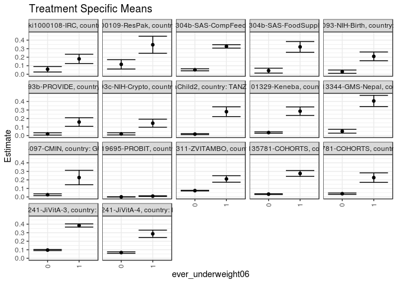

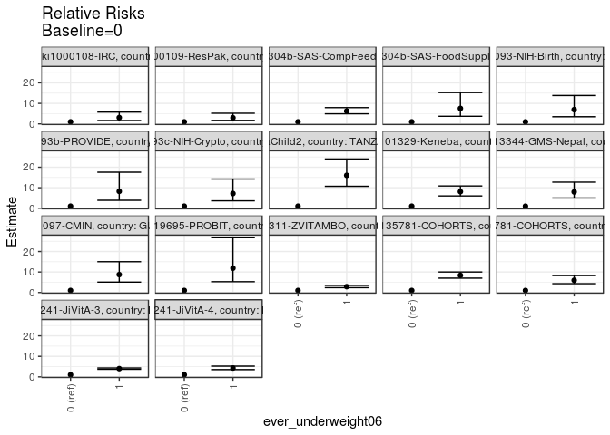

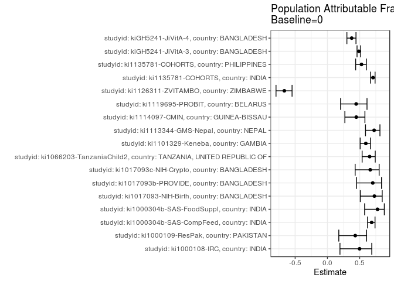

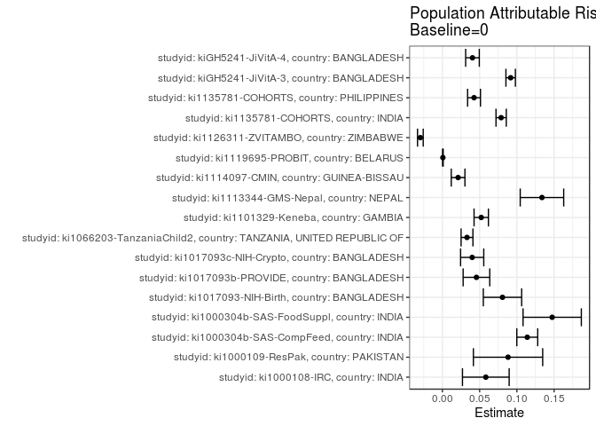

## Results Table

### Parameter: TSM

| studyid | country | intervention_level | baseline_level | estimate | ci_lower | ci_upper |
| --- | --- | --- | --- | --- | --- | --- |
| ki1000108-IRC | INDIA | 0 | NA | 0.0587560 | 0.0263752 | 0.0911369 |
| ki1000108-IRC | INDIA | 1 | NA | 0.1803243 | 0.1262574 | 0.2343912 |
| ki1000109-ResPak | PAKISTAN | 0 | NA | 0.1161846 | 0.0614579 | 0.1709113 |
| ki1000109-ResPak | PAKISTAN | 1 | NA | 0.3458727 | 0.2458170 | 0.4459285 |
| ki1000304b-SAS-CompFeed | INDIA | 0 | NA | 0.0523262 | 0.0401361 | 0.0645163 |
| ki1000304b-SAS-CompFeed | INDIA | 1 | NA | 0.3268966 | 0.3070211 | 0.3467722 |
| ki1000304b-SAS-FoodSuppl | INDIA | 0 | NA | 0.0425532 | 0.0136640 | 0.0714424 |
| ki1000304b-SAS-FoodSuppl | INDIA | 1 | NA | 0.3207547 | 0.2578442 | 0.3836653 |
| ki1017093-NIH-Birth | BANGLADESH | 0 | NA | 0.0302013 | 0.0107524 | 0.0496503 |
| ki1017093-NIH-Birth | BANGLADESH | 1 | NA | 0.2098765 | 0.1586286 | 0.2611245 |
| ki1017093b-PROVIDE | BANGLADESH | 0 | NA | 0.0193237 | 0.0060525 | 0.0325948 |
| ki1017093b-PROVIDE | BANGLADESH | 1 | NA | 0.1592040 | 0.1085836 | 0.2098244 |
| ki1017093c-NIH-Crypto | BANGLADESH | 0 | NA | 0.0202813 | 0.0080209 | 0.0325416 |
| ki1017093c-NIH-Crypto | BANGLADESH | 1 | NA | 0.1454161 | 0.0983456 | 0.1924867 |
| ki1066203-TanzaniaChild2 | TANZANIA, UNITED REPUBLIC OF | 0 | NA | 0.0174878 | 0.0113781 | 0.0235975 |
| ki1066203-TanzaniaChild2 | TANZANIA, UNITED REPUBLIC OF | 1 | NA | 0.2803680 | 0.2232791 | 0.3374568 |
| ki1101329-Keneba | GAMBIA | 0 | NA | 0.0354741 | 0.0268979 | 0.0440503 |
| ki1101329-Keneba | GAMBIA | 1 | NA | 0.2864241 | 0.2368105 | 0.3360377 |
| ki1113344-GMS-Nepal | NEPAL | 0 | NA | 0.0510332 | 0.0285505 | 0.0735159 |
| ki1113344-GMS-Nepal | NEPAL | 1 | NA | 0.4062875 | 0.3406580 | 0.4719169 |
| ki1114097-CMIN | GUINEA-BISSAU | 0 | NA | 0.0260636 | 0.0157408 | 0.0363864 |
| ki1114097-CMIN | GUINEA-BISSAU | 1 | NA | 0.2274792 | 0.1427439 | 0.3122146 |
| ki1119695-PROBIT | BELARUS | 0 | NA | 0.0008020 | 0.0000535 | 0.0015505 |
| ki1119695-PROBIT | BELARUS | 1 | NA | 0.0095252 | 0.0055582 | 0.0134921 |
| ki1126311-ZVITAMBO | ZIMBABWE | 0 | NA | 0.0739102 | 0.0698651 | 0.0779554 |
| ki1126311-ZVITAMBO | ZIMBABWE | 1 | NA | 0.2110204 | 0.1726547 | 0.2493862 |
| ki1135781-COHORTS | INDIA | 0 | NA | 0.0328978 | 0.0286961 | 0.0370996 |
| ki1135781-COHORTS | INDIA | 1 | NA | 0.2751155 | 0.2411173 | 0.3091136 |
| ki1135781-COHORTS | PHILIPPINES | 0 | NA | 0.0379611 | 0.0299015 | 0.0460207 |
| ki1135781-COHORTS | PHILIPPINES | 1 | NA | 0.2265558 | 0.1707810 | 0.2823307 |
| kiGH5241-JiVitA-3 | BANGLADESH | 0 | NA | 0.0962269 | 0.0901632 | 0.1022907 |
| kiGH5241-JiVitA-3 | BANGLADESH | 1 | NA | 0.3846620 | 0.3657754 | 0.4035485 |
| kiGH5241-JiVitA-4 | BANGLADESH | 0 | NA | 0.0669610 | 0.0582139 | 0.0757080 |
| kiGH5241-JiVitA-4 | BANGLADESH | 1 | NA | 0.2868989 | 0.2439280 | 0.3298697 |

### Parameter: E(Y)

| studyid | country | intervention_level | baseline_level | estimate | ci_lower | ci_upper |
| --- | --- | --- | --- | --- | --- | --- |
| ki1000108-IRC | INDIA | NA | NA | 0.1170732 | 0.0859146 | 0.1482317 |
| ki1000109-ResPak | PAKISTAN | NA | NA | 0.2043478 | 0.1521230 | 0.2565727 |
| ki1000304b-SAS-CompFeed | INDIA | NA | NA | 0.1663067 | 0.1478935 | 0.1847199 |
| ki1000304b-SAS-FoodSuppl | INDIA | NA | NA | 0.1900000 | 0.1515071 | 0.2284929 |
| ki1017093-NIH-Birth | BANGLADESH | NA | NA | 0.1109057 | 0.0844206 | 0.1373909 |
| ki1017093b-PROVIDE | BANGLADESH | NA | NA | 0.0650407 | 0.0455353 | 0.0845460 |
| ki1017093c-NIH-Crypto | BANGLADESH | NA | NA | 0.0602740 | 0.0429977 | 0.0775502 |
| ki1066203-TanzaniaChild2 | TANZANIA, UNITED REPUBLIC OF | NA | NA | 0.0505451 | 0.0409848 | 0.0601054 |
| ki1101329-Keneba | GAMBIA | NA | NA | 0.0876266 | 0.0759950 | 0.0992582 |
| ki1113344-GMS-Nepal | NEPAL | NA | NA | 0.1847458 | 0.1534039 | 0.2160876 |
| ki1114097-CMIN | GUINEA-BISSAU | NA | NA | 0.0471513 | 0.0341242 | 0.0601783 |
| ki1119695-PROBIT | BELARUS | NA | NA | 0.0014461 | 0.0004206 | 0.0024716 |
| ki1126311-ZVITAMBO | ZIMBABWE | NA | NA | 0.0443281 | 0.0404267 | 0.0482294 |
| ki1135781-COHORTS | INDIA | NA | NA | 0.1117877 | 0.1043506 | 0.1192249 |
| ki1135781-COHORTS | PHILIPPINES | NA | NA | 0.0804557 | 0.0703953 | 0.0905161 |
| kiGH5241-JiVitA-3 | BANGLADESH | NA | NA | 0.1879125 | 0.1813641 | 0.1944608 |
| kiGH5241-JiVitA-4 | BANGLADESH | NA | NA | 0.1073532 | 0.0971813 | 0.1175251 |

### Parameter: RR

| studyid | country | intervention_level | baseline_level | estimate | ci_lower | ci_upper |
| --- | --- | --- | --- | --- | --- | --- |
| ki1000108-IRC | INDIA | 0 | 0 | 1.000000 | 1.000000 | 1.000000 |
| ki1000108-IRC | INDIA | 1 | 0 | 3.069034 | 1.638157 | 5.749737 |
| ki1000109-ResPak | PAKISTAN | 0 | 0 | 1.000000 | 1.000000 | 1.000000 |
| ki1000109-ResPak | PAKISTAN | 1 | 0 | 2.976923 | 1.711620 | 5.177594 |
| ki1000304b-SAS-CompFeed | INDIA | 0 | 0 | 1.000000 | 1.000000 | 1.000000 |
| ki1000304b-SAS-CompFeed | INDIA | 1 | 0 | 6.247285 | 4.928462 | 7.919017 |
| ki1000304b-SAS-FoodSuppl | INDIA | 0 | 0 | 1.000000 | 1.000000 | 1.000000 |
| ki1000304b-SAS-FoodSuppl | INDIA | 1 | 0 | 7.537735 | 3.718279 | 15.280577 |
| ki1017093-NIH-Birth | BANGLADESH | 0 | 0 | 1.000000 | 1.000000 | 1.000000 |
| ki1017093-NIH-Birth | BANGLADESH | 1 | 0 | 6.949245 | 3.490055 | 13.837033 |
| ki1017093b-PROVIDE | BANGLADESH | 0 | 0 | 1.000000 | 1.000000 | 1.000000 |
| ki1017093b-PROVIDE | BANGLADESH | 1 | 0 | 8.238806 | 3.865305 | 17.560819 |
| ki1017093c-NIH-Crypto | BANGLADESH | 0 | 0 | 1.000000 | 1.000000 | 1.000000 |
| ki1017093c-NIH-Crypto | BANGLADESH | 1 | 0 | 7.169969 | 3.611037 | 14.236482 |
| ki1066203-TanzaniaChild2 | TANZANIA, UNITED REPUBLIC OF | 0 | 0 | 1.000000 | 1.000000 | 1.000000 |
| ki1066203-TanzaniaChild2 | TANZANIA, UNITED REPUBLIC OF | 1 | 0 | 16.032228 | 10.699932 | 24.021867 |
| ki1101329-Keneba | GAMBIA | 0 | 0 | 1.000000 | 1.000000 | 1.000000 |
| ki1101329-Keneba | GAMBIA | 1 | 0 | 8.074174 | 5.999689 | 10.865943 |
| ki1113344-GMS-Nepal | NEPAL | 0 | 0 | 1.000000 | 1.000000 | 1.000000 |
| ki1113344-GMS-Nepal | NEPAL | 1 | 0 | 7.961239 | 4.982379 | 12.721096 |
| ki1114097-CMIN | GUINEA-BISSAU | 0 | 0 | 1.000000 | 1.000000 | 1.000000 |
| ki1114097-CMIN | GUINEA-BISSAU | 1 | 0 | 8.727852 | 5.068466 | 15.029280 |
| ki1119695-PROBIT | BELARUS | 0 | 0 | 1.000000 | 1.000000 | 1.000000 |
| ki1119695-PROBIT | BELARUS | 1 | 0 | 11.876718 | 5.276562 | 26.732640 |
| ki1126311-ZVITAMBO | ZIMBABWE | 0 | 0 | 1.000000 | 1.000000 | 1.000000 |
| ki1126311-ZVITAMBO | ZIMBABWE | 1 | 0 | 2.855091 | 2.359538 | 3.454721 |
| ki1135781-COHORTS | INDIA | 0 | 0 | 1.000000 | 1.000000 | 1.000000 |
| ki1135781-COHORTS | INDIA | 1 | 0 | 8.362721 | 7.001737 | 9.988251 |
| ki1135781-COHORTS | PHILIPPINES | 0 | 0 | 1.000000 | 1.000000 | 1.000000 |
| ki1135781-COHORTS | PHILIPPINES | 1 | 0 | 5.968112 | 4.313631 | 8.257164 |
| kiGH5241-JiVitA-3 | BANGLADESH | 0 | 0 | 1.000000 | 1.000000 | 1.000000 |
| kiGH5241-JiVitA-3 | BANGLADESH | 1 | 0 | 3.997446 | 3.693405 | 4.326516 |
| kiGH5241-JiVitA-4 | BANGLADESH | 0 | 0 | 1.000000 | 1.000000 | 1.000000 |
| kiGH5241-JiVitA-4 | BANGLADESH | 1 | 0 | 4.284567 | 3.512782 | 5.225921 |

### Parameter: PAR

| studyid | country | intervention_level | baseline_level | estimate | ci_lower | ci_upper |
| --- | --- | --- | --- | --- | --- | --- |
| ki1000108-IRC | INDIA | 0 | NA | 0.0583171 | 0.0269637 | 0.0896706 |
| ki1000109-ResPak | PAKISTAN | 0 | NA | 0.0881632 | 0.0416339 | 0.1346924 |
| ki1000304b-SAS-CompFeed | INDIA | 0 | NA | 0.1139805 | 0.0999485 | 0.1280125 |
| ki1000304b-SAS-FoodSuppl | INDIA | 0 | NA | 0.1474468 | 0.1083088 | 0.1865848 |
| ki1017093-NIH-Birth | BANGLADESH | 0 | NA | 0.0807044 | 0.0549555 | 0.1064533 |
| ki1017093b-PROVIDE | BANGLADESH | 0 | NA | 0.0457170 | 0.0278436 | 0.0635904 |
| ki1017093c-NIH-Crypto | BANGLADESH | 0 | NA | 0.0399927 | 0.0244317 | 0.0555537 |
| ki1066203-TanzaniaChild2 | TANZANIA, UNITED REPUBLIC OF | 0 | NA | 0.0330573 | 0.0251047 | 0.0410100 |
| ki1101329-Keneba | GAMBIA | 0 | NA | 0.0521525 | 0.0425103 | 0.0617946 |
| ki1113344-GMS-Nepal | NEPAL | 0 | NA | 0.1337126 | 0.1045171 | 0.1629080 |
| ki1114097-CMIN | GUINEA-BISSAU | 0 | NA | 0.0210877 | 0.0119119 | 0.0302635 |
| ki1119695-PROBIT | BELARUS | 0 | NA | 0.0006441 | 0.0002325 | 0.0010558 |
| ki1126311-ZVITAMBO | ZIMBABWE | 0 | NA | -0.0295822 | -0.0333985 | -0.0257658 |
| ki1135781-COHORTS | INDIA | 0 | NA | 0.0788899 | 0.0719965 | 0.0857833 |
| ki1135781-COHORTS | PHILIPPINES | 0 | NA | 0.0424946 | 0.0338521 | 0.0511371 |
| kiGH5241-JiVitA-3 | BANGLADESH | 0 | NA | 0.0916855 | 0.0853184 | 0.0980527 |
| kiGH5241-JiVitA-4 | BANGLADESH | 0 | NA | 0.0403922 | 0.0312311 | 0.0495534 |

### Parameter: PAF

| studyid | country | intervention_level | baseline_level | estimate | ci_lower | ci_upper |
| --- | --- | --- | --- | --- | --- | --- |
| ki1000108-IRC | INDIA | 0 | NA | 0.4981256 | 0.1944498 | 0.6873218 |
| ki1000109-ResPak | PAKISTAN | 0 | NA | 0.4314369 | 0.1763733 | 0.6075115 |
| ki1000304b-SAS-CompFeed | INDIA | 0 | NA | 0.6853633 | 0.6225617 | 0.7377154 |
| ki1000304b-SAS-FoodSuppl | INDIA | 0 | NA | 0.7760358 | 0.5768128 | 0.8814710 |
| ki1017093-NIH-Birth | BANGLADESH | 0 | NA | 0.7276846 | 0.5090700 | 0.8489485 |
| ki1017093b-PROVIDE | BANGLADESH | 0 | NA | 0.7028985 | 0.4528294 | 0.8386805 |
| ki1017093c-NIH-Crypto | BANGLADESH | 0 | NA | 0.6635152 | 0.4296021 | 0.8015034 |
| ki1066203-TanzaniaChild2 | TANZANIA, UNITED REPUBLIC OF | 0 | NA | 0.6540164 | 0.5378956 | 0.7409576 |
| ki1101329-Keneba | GAMBIA | 0 | NA | 0.5951673 | 0.5070405 | 0.6675397 |
| ki1113344-GMS-Nepal | NEPAL | 0 | NA | 0.7237653 | 0.5902495 | 0.8137754 |
| ki1114097-CMIN | GUINEA-BISSAU | 0 | NA | 0.4472345 | 0.2705742 | 0.5811093 |
| ki1119695-PROBIT | BELARUS | 0 | NA | 0.4454140 | 0.2043962 | 0.6134186 |
| ki1126311-ZVITAMBO | ZIMBABWE | 0 | NA | -0.6673460 | -0.7962630 | -0.5476814 |
| ki1135781-COHORTS | INDIA | 0 | NA | 0.7057115 | 0.6690009 | 0.7383507 |
| ki1135781-COHORTS | PHILIPPINES | 0 | NA | 0.5281743 | 0.4377210 | 0.6040765 |
| kiGH5241-JiVitA-3 | BANGLADESH | 0 | NA | 0.4879162 | 0.4589755 | 0.5153088 |
| kiGH5241-JiVitA-4 | BANGLADESH | 0 | NA | 0.3762555 | 0.3019112 | 0.4426823 |